# Yelp Review Rating Prediction

EC349 Data Science For Economists (2023/24)

Daniel Dzhiris (u2150766)

2023-12-02

## Tabula statement

We’re part of an academic community at Warwick.

Whether studying, teaching, or researching, we’re all taking part in an expert conversation which must meet standards of academic integrity. When we all meet these standards, we can take pride in our own academic achievements, as individuals and as an academic community.

Academic integrity means committing to honesty in academic work, giving credit where we’ve used others’ ideas and being proud of our own achievements.

In submitting my work I confirm that:

1. I have read the guidance on academic integrity provided in the Student Handbook and understand the University regulations in relation to Academic Integrity. I am aware of the potential consequences of Academic Misconduct.
2. I declare that the work is all my own, except where I have stated otherwise.
3. No substantial part(s) of the work submitted here has also been submitted by me in other credit bearing assessments courses of study (other than in certain cases of a resubmission of a piece of work), and I acknowledge that if this has been done this may lead to an appropriate sanction.
4. Where a generative Artificial Intelligence such as ChatGPT has been used I confirm I have abided by both the University guidance and specific requirements as set out in the Student Handbook and the Assessment brief. I have clearly acknowledged the use of any generative Artificial Intelligence in my submission, my reasoning for using it and which generative AI (or AIs) I have used. Except where indicated the work is otherwise entirely my own.
5. I understand that should this piece of work raise concerns requiring investigation in relation to any of points above, it is possible that other work I have submitted for assessment will be checked, even if marks (provisional or confirmed) have been published.
6. Where a proof-reader, paid or unpaid was used, I confirm that the proofreader was made aware of and has complied with the University’s proofreading policy.
7. I consent that my work may be submitted to Turnitin or other analytical technology. I understand the use of this service (or similar), along with other methods of maintaining the integrity of the academic process, will help the University uphold academic standards and assessment fairness.

Privacy statement

The data on this form relates to your submission of coursework. The date and time of your submission, your identity, and the work you have submitted will be stored. We will only use this data to administer and record your coursework submission.

Related articles

Reg. 11 Academic Integrity (from 4 Oct 2021)

Guidance on Regulation 11

Proofreading Policy

Education Policy and Quality Team

Academic Integrity (warwick.ac.uk)

## Introduction

Customer reviews posted online constitute one of the most powerful channels for exerting a persuasive influence on customers’ perceptions of product quality. According to McKinsey’s research (2022), insights from fellow consumers have a greater sway over individuals than any marketing strategy. Yelp is a widely used crowd-sourced platform for local business reviews. For each individual business, users can submit a rating on a scale of one to five stars and share comprehensive descriptions of their experiences.

This project aims to predict ratings assigned to each review, utilising both the text review itself and several other variables explored in later paragraphs. The paper will begin by analysing the dataset to identify the required data for predicting review ratings. It will delve into the data preparation procedures implemented to make the data suitable for forecasting. The assessment of the selected model will be provided, concluding with final remarks regarding the selected DS methodology and the most difficult challenge of the project. The code is publicly available on GitHub[^1].

## Data Understanding and Preparation

The Yelp data set consists of separate files for each object type: business, review, user, check-in, and tips from users. The trimmed version of the reviews data set we use contains 1,398,056 reviews, where users give a star rating complemented by a text review. Figure 1 shows that the star ratings do not follow a uniform distribution, with 67% of reviews having at least four stars. Moreover, the differences between ratings are inconsistent across the entire range of star ratings. The difference between a 2-star and a 3-star rating might carry a different level of significance than the difference between a 4-star and a 5-star rating. Therefore, review rating prediction is treated as a classification problem, and a non-linear model is required to make accurate predictions.

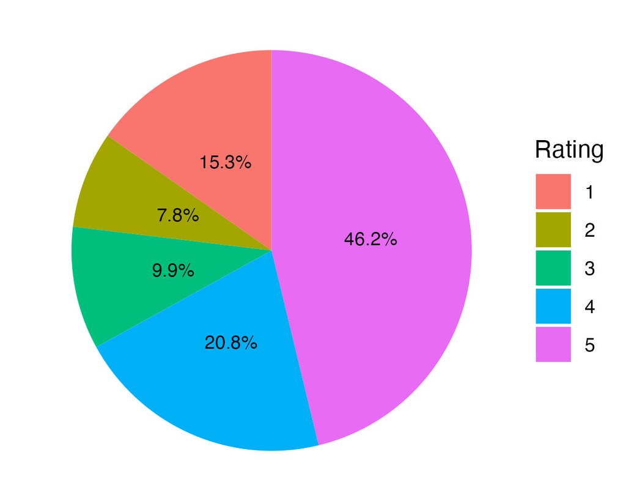

**Figure 1:** *Distribution of Reviews by Star Rating*

The data set also provides information on a business’s average rating, which indicates its overall reputation and customer satisfaction. Furthermore, businesses with higher average ratings are likely to receive better reviews. Customers often base their expectations on the overall reputation of a business, which can influence the star rating they assign in their reviews. Including the average rating of a business in the model allows it to account for the baseline satisfaction associated with a particular establishment.

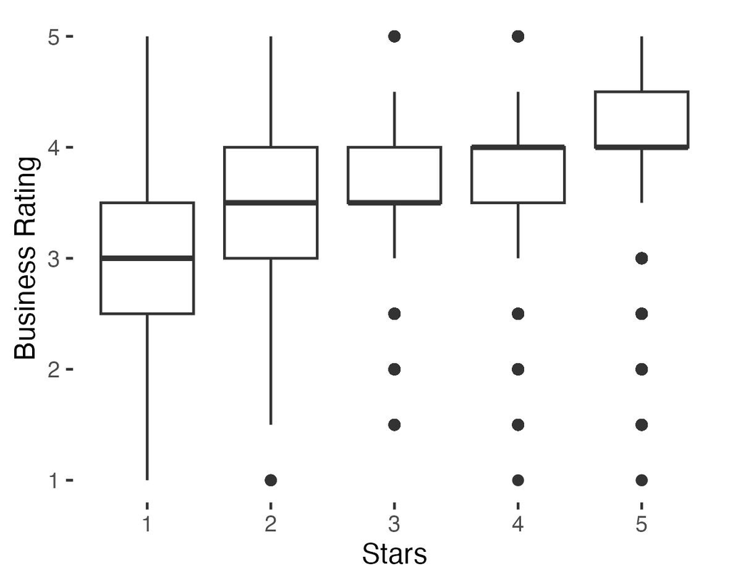

**Figure 2:** *Boxplot of Business Ratings Across Star Categories*

Similarly, we include a variable for average ratings given by a user, as user-specific ratings offer insights into the individual’s reviewing patterns and inclinations. For instance, individuals who consistently assign low ratings may utilise the Yelp platform primarily for sharing negative reviews.

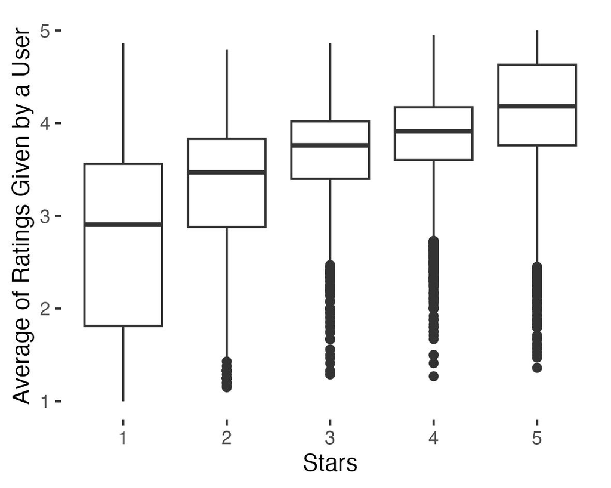

**Figure 3:** *Boxplot of User’s Average Ratings Across Star Categories*

Additionally, we find that longer reviews tend to have lower ratings. Negative experiences or issues with a product or service could be more complex and might require more details. Customers may need to share specific examples when describing their negative encounters, leading to longer reviews. Additionally, the heightened emotional impact of negative experiences may foster greater emotional engagement, prompting customers to express their dissatisfaction in more extensive and detailed reviews.

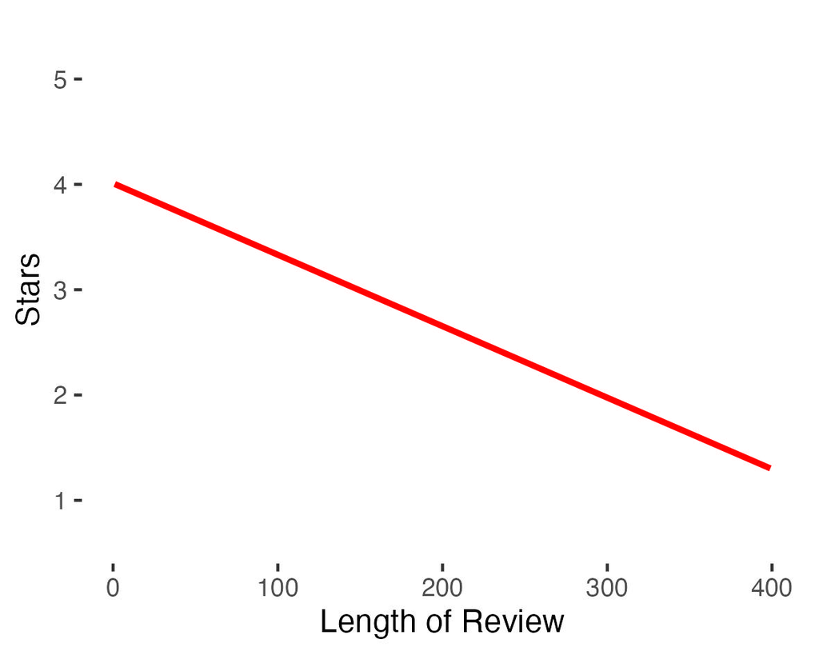

**Figure 4:** *Regression Line of Review Length and Star Ratings*

Lastly, the fourth variable incorporated into the model is the normalised sentiment score derived from the text review. Treating a review as a composite of its constituent words, each word is assigned a sentiment score ranging from -5 to 5 based on the AFINN sentiment lexicon. The cumulative sentiment score is determined by summing the sentiment values assigned to each individual word in the review, and this total is normalised by the number of tokenised words in the review. Furthermore, a set of negation words is employed[^2]; if any of these words precede a sentiment word, the sentiment score is reversed in the opposite direction.

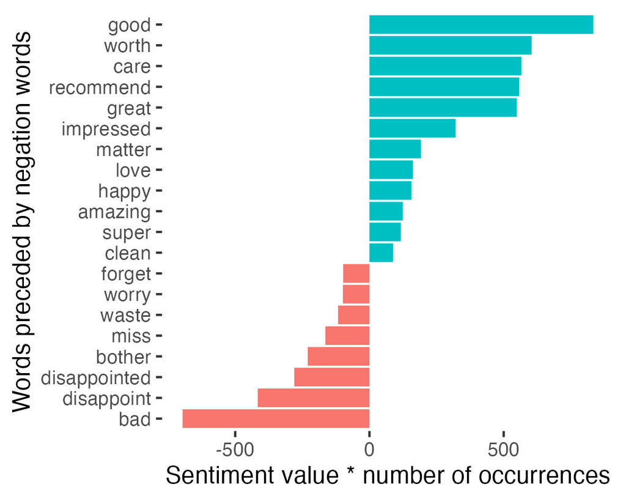

**Figure 5:** *Words that contributed the most to sentiment when they followed a ‘negating’ word*

## The Model

Since the paper assumes a complex non-linear relationship between the star rating and the selected explanatory variables, the focus will be on classification trees. Table 1 (see Appendix) shows that the independent variables have a moderately high correlation, and one strong predictor is likely to be always used in the top split. Consequently, the predictions from the bagged trees will be highly correlated and averaging them will not lead to a large reduction in variance. Therefore, I have implemented a random forest model, which effectively decorrelates the trees.

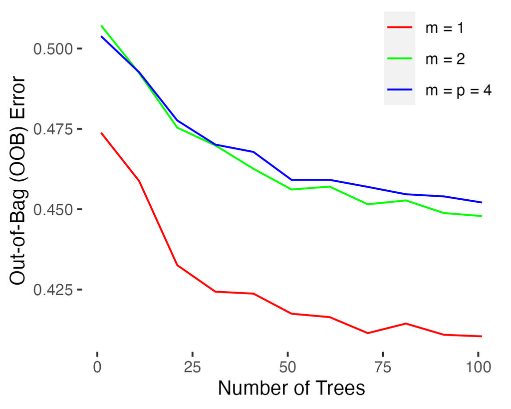

**Figure 6:** *Results from random forests with p = 4 predictors. The Out-of-Bag error is displayed as a function of the number of trees. Each coloured line corresponds to a different value of m, the number of predictors available for splitting at each interior tree node. Random forests (m < p) lead to an improvement over bagging (m = p). A single classification tree has an error rate of 48%*

## Results and Evaluation

Table 2 (see Appendix) shows the confusion matrix for the test data set, a random sample of 10,000 observations. The accuracy of the random forest model is 60.4%, whereas the majority class percentage is 46.2%.

However, the misclassification error rate is significantly higher for 2, 3 and 4-star reviews, possibly due to the imbalanced nature of the data set with 5-star reviews dominating. Therefore, the model may be biased towards the majority class. Future studies could employ techniques like class weighting or resampling.

Furthermore, the Yelp data set contains businesses from various sectors, including hotels and restaurants. Due to the unique characteristics of text reviews specific to each business type, it is important to perform Review Rating Prediction independently for each category. Currently, there is no variable indicating the business category, and prospective research projects could implement a machine learning classifier to predict a business’s industry based on its text reviews.

Lastly, it is important to note that sentiment analysis proved to be resource-intensive in terms of both time and memory. Consequently, the total number of observations used in training and testing the model was limited to 30,000. Exploring a larger set of observations could be valuable to assess if it produces different results.

## DS Methodology

I implemented John Rollins’ DS Methodology due to its structured approach and iterative nature. The project started with understanding the goal of the analysis and identifying what technique would best address it. While delving deeper into the data, I found myself revisiting earlier stages to make refinements. Specifically, during the evaluation phase, I discovered that the word “good” had been omitted from sentiment analysis since it was part of the stop words list. Consequently, I went back to the data preparation stage to create a customised stop words list, omitting words like “good” and “great” from the standard tidytext list of stop words.

## Statement on the Most Difficult Challenge

The most difficult challenge was to select the relevant predictors, as the Yelp data set has many different variables. The appropriate data is crucial for developing an accurate model, and including a large number of variables is not always beneficial since it reduces the interpretability of the model. Therefore, I have relied on logical reasoning to identify relevant features. The key was to unravel the narrative within the data, which allowed me to create a logical storyline. I particularly enjoyed using descriptive statistics and visualisation techniques to understand the data, assess its quality, and discover initial insights about the reviews.

## References

McKinsey (2022). *Why business must heed customer reviews.* [online] Available at: https://www.mckinsey.com/capabilities/operations/our-insights/why-business-must-heed-customer-reviews.

## Appendix

**Table 1:** *Correlation Matrix*

|  | afinn_sentiment_norm | business_rating | average_stars | total_tokens |
| --- | --- | --- | --- | --- |
| **afinn_sentiment_norm** | 1 | 0.304 | 0.376 | -0.299 |
| **business_rating** | 0.304 | 1 | 0.305 | -0.067 |
| **average_stars** | 0.376 | 0.305 | 1 | -0.097 |
| **total_tokens** | -0.299 | -0.067 | -0.097 | 1 |

**Table 2:** *Confusion Matrix for Testing Data using Random Forest*

|  | 1 | 2 | 3 | 4 | 5 | Class Error |
| --- | --- | --- | --- | --- | --- | --- |
| **1** | 1306 | 362 | 188 | 96 | 96 | 36.2% |
| **2** | 45 | 55 | 40 | 23 | 19 | 69.8% |
| **3** | 31 | 49 | 64 | 62 | 26 | 72.4% |
| **4** | 57 | 114 | 262 | 488 | 351 | 61.6% |
| **5** | 112 | 174 | 430 | 1420 | 4130 | 34.1% |

**Figure 7:** *Variable Importance Plot*

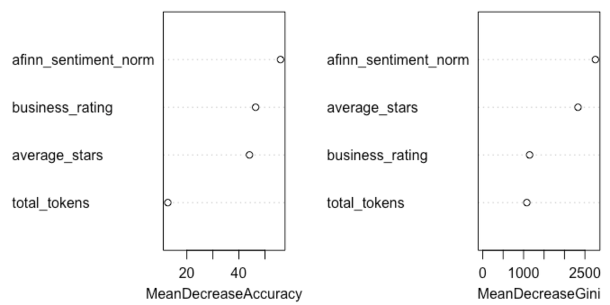

[^1]: https://github.com/danieldzhiriswarwick/EC349-Project
[^2]: Negation words: “not”, “no”, “never”, “without”, “isn’t”, “aren’t”, “doesn’t”, “don’t”, “didn’t”, “hasn’t”, “haven’t”